# Peer Assignment 1

William Chan

Thursday, August 14, 2014

I. During the data processing step, the dataset will be loaded into R and reformat date that is appropriate for further analysis

```r
data <- read.csv("activity.csv")
data$date <- as.Date(data$date, format = "%Y-%m-%d")
```

2. Calcuate the mean total number of steps taken per day Create a histogram of the total number of stpes each day

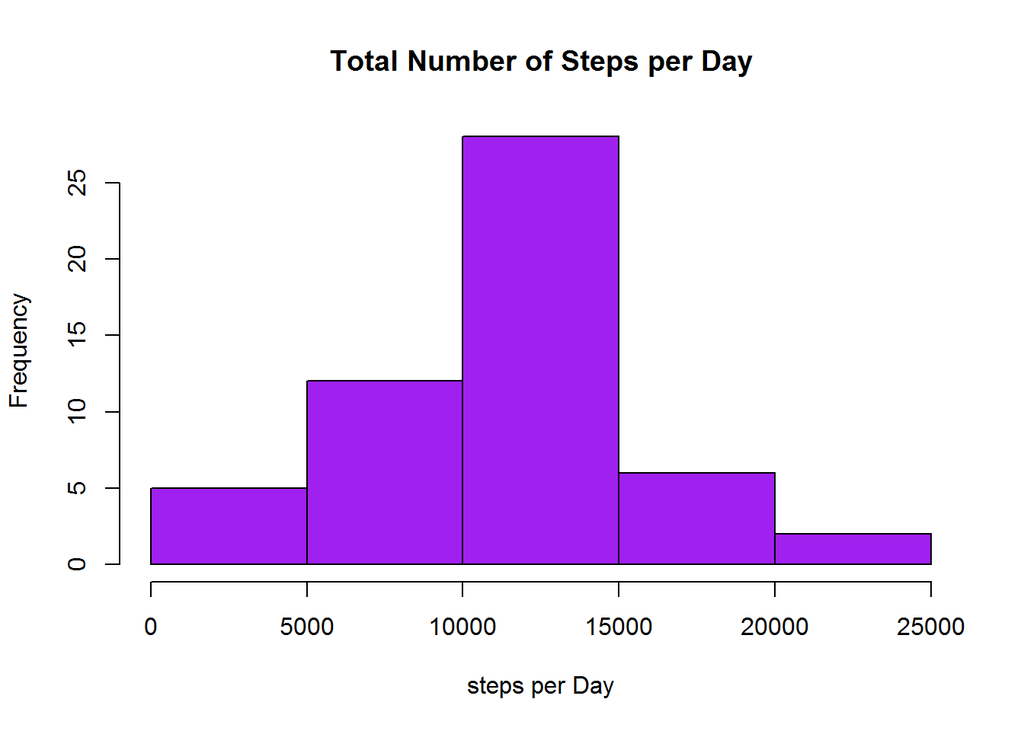

```
 Calculate the mean and median total number of steps taken per day
```

```r
dailysteps <- aggregate(steps ~ date, data = data, FUN = sum)
hist(dailysteps$steps, col = "purple", main = "Total Number of Steps per Day",
     xlab = "steps per Day")
```

```r
meanStep <- format(mean(dailysteps$steps), digits=5, decimal.mark=",")
medianStep <- median(dailysteps$steps)
```

The mean of the total number of steps taken per day is **10766** while the median is **10765**. III. Calculate the average daily activity pattern Creating a time series plot

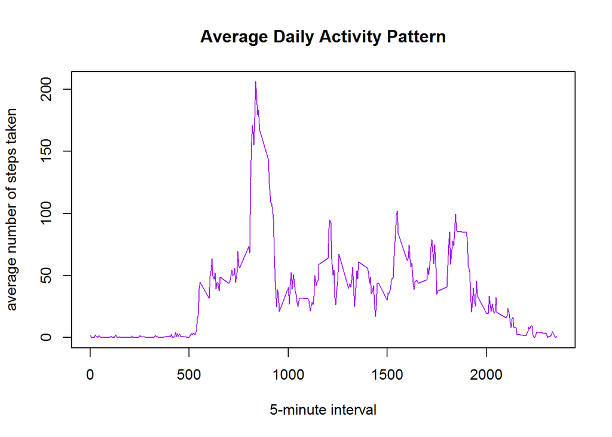

[output not shown]

```r
interval <- aggregate(steps ~ interval, data = data, FUN = mean)
plot(interval$interval, interval$steps, type = "l", col = "purple",
     main = "Average Daily Activity Pattern",
     xlab = "5-minute interval", ylab = "average number of steps taken")
```

```r
maxSteps <- interval$interval[interval$steps == max(interval$steps)]
```

4. Determine missing values Calculate the total number of missing values in the dataset

```r
na <- sum(is.na(data))
```

The total number of rows with missing values are **2304**.

```
 Devise a strategy for filling in all the missing values
```

The strategy used to impute the missing values within the steps variable was to use the VIM R package. The VIM package contains kNN function to impute values using Euclidean distance among the numerical variable. The dataset with imputed missing values is called imputeData.

```r
library(VIM)
imputeData <- kNN(data)
```

```
## Time difference of -4.473 secs
```

[output not shown]

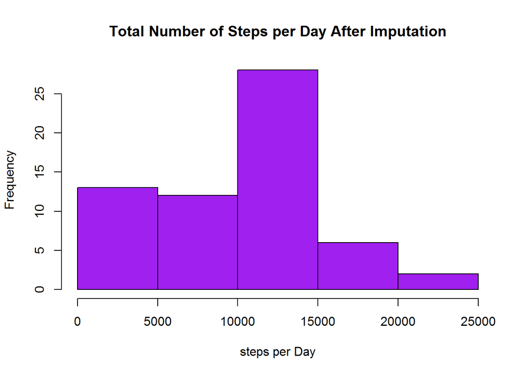

```r
imputesteps <- aggregate(steps ~ date, data = imputeData, FUN = sum)
hist(imputesteps$steps, col = "purple", main = "Total Number of Steps per Day After Imputation",
     xlab = "steps per Day")
```

```r
imputeMean <- mean(imputeData$steps)
imputeMedian <- median(imputeData$steps)
```

V. Are there differences in activity patterns between weekdays and weekends? After creating the day variable, then we can create new weekday and weekend variables by using the sqldf package.

```r
imputeData$day <- weekdays(imputeData$date)
library(sqldf)
weekend <- sqldf("select * from imputeData where day = 'Saturday' or
                 day = 'Sunday'")
weekday <- sqldf("select * from imputeData where day != 'Saturday' or
                 day != 'Sunday'")
```

[output not shown]

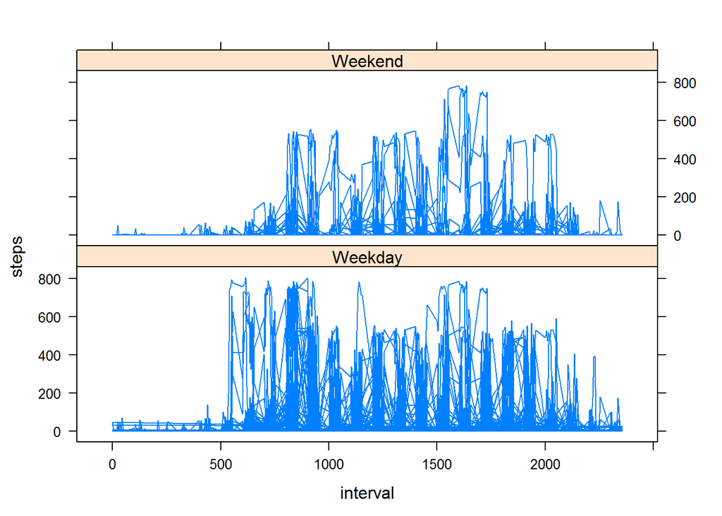

```r
library(lattice)
xyplot(steps ~ interval|which, make.groups(Weekday = weekday, Weekend = weekend),
       type = "l", layout = c(1,2), auto.key = T)
```